# Chapter 7

## Conceptual

### Excercise 1a

When there is only one knot and for all $x \le \xi$, ${f_1}(x) = {a_1} + {b_1}x + {c_1}{x^2} + {d_1}{x^3}$ can be transformed into $f(x) = {\beta _0} + {\beta _1}x + {\beta _2}{x^2} + {\beta _3}{x^3}$ when ${a_1} = {\beta _0},{b_1} = {\beta _1},{c_1} = {\beta _2},{d_1} = {\beta _3}$

### Excercise 1b

For all $x > \xi$, $\begin{array}{l} f(x) &=& {\beta _0} + {\beta _1}x + {\beta _2}{x^2} + {\beta _3}{x^3} + {\beta _4}{(x - \xi )^3}\\ &=& {\beta _0} + {\beta _1}x + {\beta _2}{x^2} + {\beta _3}{x^3} + {\beta _4}({x^3} + 3{\xi ^2}x - 3\xi {x^2} - {\xi ^3})\\ &=& {\beta _0} + {\beta _1}x + {\beta _2}{x^2} + {\beta _3}{x^3} + {\beta _4}{x^3} + 3{\xi ^2}{\beta _4}x - 3\xi {\beta _4}{x^2} - {\xi ^3}{\beta _4}\\ &=& {\beta _0} - {\xi ^3}{\beta _4} + ({\beta _1} + 3{\xi ^2}{\beta _4})x + ({\beta _2} - 3\xi {\beta _4}){x^2} + ({\beta _3} + {\beta _4}){x^3} \end{array}$ Therefore, above equation can be transformed from ${f_2}(x) = {a_2} + {b_2}x + {c_2}{x^2} + {d_2}{x^3}$, when ${a_2} = {\beta _0} - {\xi ^3}{\beta _4},{b_2} = {\beta _1} + 3{\xi ^2}{\beta _4},{c_2} = {\beta _2} - 3\xi {\beta _4},{d_2} = {\beta _3} + {\beta _4}$

### Excercise 1c

When $x = \xi$, we have the form of ${f_2}(\xi)$: $\begin{array}{l} {f_2}(\xi) &=& {\beta _0} - {\xi ^3}{\beta _4} + ({\beta _1} + 3{\xi ^2}{\beta _4})\xi + ({\beta _2} - 3\xi {\beta _4}){\xi ^2} + ({\beta _3} + {\beta _4}){\xi ^3}\\ &=& {\beta _0} - {\xi ^3}{\beta _4} + {\beta _1}\xi + 3{\xi ^3}{\beta _4} + {\beta _2}{\xi ^2} - 3{\xi ^3}{\beta _4} + {\beta _3}{\xi ^3} + {\beta _4}{\xi ^3}\\ &=& {\beta _0} + {\beta _1}\xi + {\beta _2}{\xi ^2} + {\beta _3}{\xi ^3}\\ &=& {f_1}(\xi) \end{array}$

### Excercise 1d

When $x = \xi$, we have the form of ${{f'}_1}(x)$: $\begin{array}{l} {{f'}_1}(x) &=& {\beta _1} + 2{\beta _2}x + 3{\beta _3}{x^2}\\ {{f'}_1}(\xi ) &=& {\beta _1} + 2{\beta _2}\xi + 3{\beta _3}{\xi ^2} \end{array}$ and the form of ${{f'}_2}(x)$: $\begin{array}{l} {{f'}_2}(x) &=& {\beta _1} + 3{\xi ^2}{\beta _4} + 2({\beta _2} - 3\xi {\beta _4})x + 3({\beta _3} + {\beta _4}){x^2}\\ &=& {\beta _1} + 3{\xi ^2}{\beta _4} + 2{\beta _2}x - 6\xi {\beta _4}x + 3{\beta _3}{x^2} + 3{\beta _4}{x^2}\\ {{f'}_2}(\xi ) &=& {\beta _1} + 2{\beta _2}\xi + 3{\beta _4}{\xi ^2} - 6{\beta _4}{\xi ^2} + 3{\beta _3}{\xi ^2} + 3{\beta _4}{\xi ^2}\\ &=& {\beta _1} + 2{\beta _2}\xi + (3{\beta _4} - 6{\beta _4} + 3{\beta _3} + 3{\beta _4}){\xi ^2}\\ &=& {\beta _1} + 2{\beta _2}\xi + 3{\beta _3}{\xi ^2} \end{array}$ Therefore, ${{f'}_1}(\xi ) = {{f'}_2}(\xi )$.

### Excercise 1e

We will take the derivatives of ${f_1}(x)$ with the form of $a_1, b_1, c_1$, and $d_1$ for simplicity: $\begin{array}{l} {f_1}(x) = {a_1} + {b_1}x + {c_1}{x^2} + {d_1}{x^3}\\ {{f'}_1}(x) = {b_1} + 2{c_1}x + 3{d_1}{x^2}\\ {{f''}_1}(x) = 2{c_1} + 6{d_1}x \end{array}$ By substituting ${c_1} = {\beta _2}$and ${d_1} = {\beta _3}$ into above equation with $x = \xi$: ${{f''}_1}(\xi) = 2{\beta _2} + 6{\beta _3}\xi$ Similarily, ${{f''}_2}(x) = 2{c_2} + 6{d_2}x$ Again, by substituting ${c_2} = {\beta _2} - 3\xi {\beta _4}$ and ${d_2} = {\beta _3} + {\beta _4}$ into above equation with $x = \xi$, we have: $\begin{array}{l} {{f''}_2}(\xi) &=& 2{\beta _2} - 6\xi {\beta _4} + 6({\beta _3} + {\beta _4})\xi\\ &=& 2{\beta _2} + 6{\beta _3}\xi \end{array}$

Therefore, we have ${{f''}_1}(\xi ) = {{f''}_2}(\xi )$.

### Excercise 2a

${g^0}(x) = g(x)$ and the $\hat g$ will minimize over the sum of $y_i$.

### Excercise 2b

Since the sum of slopes of $g(x)$ supressed to zero, $\hat g$ will be ${\rm E}(y)$ (mean of $y$): a horizontal line parallel to x axis.

### Excercise 2c

Since the total change of slope of $g(x)$ is supressed to zero, $\hat g$ will be a straight line that passes as closely as possible to the training points (i.e. a linear squares line).

### Excercise 2d

The sum of rate of change of slop for $g(x)$ will be supressed to zero. Since the third derivative doesn’t give a lot of information about the function itself, therefore supressing third derivative will not help/deteriorate in choosing $\hat g$ along with minimization of RSS. Thus, this formula amounts to the linear regression choosing $\hat g$ based on minimizing RSS.

### Excercise 2e

The penalty term doesn’t matter, and this formula amounts to the linear regression choosing $\hat g$ based on minimizing RSS.

### Excercise 3

Substituting ${\hat \beta _0} = 1, {\hat \beta _1} = 1$ and ${\hat \beta _2} = -2$, we have: $\begin{array}{*{20}{l}} {Y = {\beta _0} + {\beta _1}{b_1}(X) + {\beta _2}{b_2}(X) + \varepsilon }\\ {\hat Y = 1 + X - 2{{(X - 1)}^2}I(X \ge 1)}\\ { = \left\{ {\begin{array}{*{20}{l}} {1 + X,X < 1}\\ { - 1 + 5X - 2{X^2},X \ge 1} \end{array}} \right.} \end{array}$

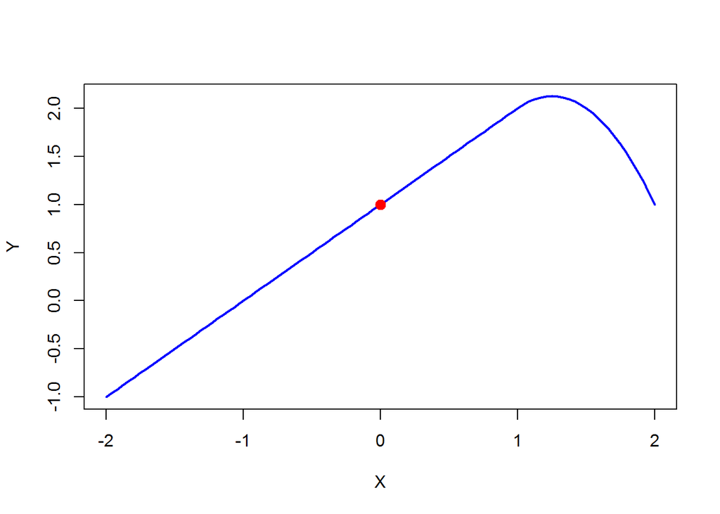

```r
x_l = seq(-2, 1, length.out = 75)
y_l = 1 + x_l
x_r = seq(1, 2, length.out = 25)
y_r = -1 + 5*x_r - 2*x_r^2
plot(c(x_l[-75], x_r), c(y_l[-75], y_r), type = "l", col = "blue", lwd = 2, xlab = "X", ylab = "Y")
points(0, 1,  col = "red", cex = 2, pch = 20)
```

### Excercise 4

$\begin{array}{l} Y &=& {\beta _0} + {\beta _1}{b_1}(X) + {\beta _2}{b_2}(X) + \varepsilon \\ &=& {\beta _0} + {\beta _1}(I(0 \le X \le 2) - (X - 1)I(1 \le X \le 2)) + {\beta _2}((X - 1)I(3 \le X \le 4) + I(4 < X \le 5)) + \varepsilon \\ \hat Y &=& \left\{ \begin{array}{l} 1,X < 0,2 < X < 3,5 < X\\ 2,0 \le X < 1\\ 3 - X,1 \le X \le 2\\ 3X - 2,3 \le X \le 4\\ 4,4 < X \le 5 \end{array} \right. \end{array}$

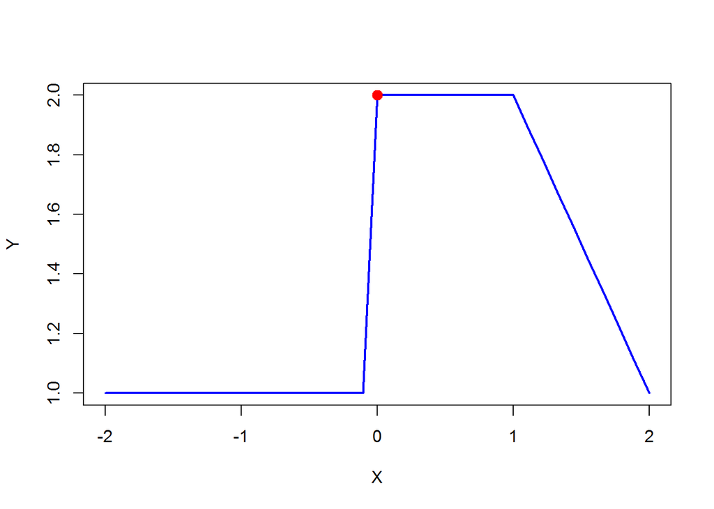

```r
x_1 = seq(-2, 0, length.out = 20)[-20]; y_1 = rep(1, length(x_1))
x_2 = seq(0, 1, length.out = 10)[-10]; y_2 = rep(2, length(x_2))
x_3 = seq(1, 2, length.out = 10); y_3 = 3 - x_3
plot(c(x_1, x_2, x_3), c(y_1, y_2, y_3), type = "l", col = "blue", lwd = 2, xlab = "X", ylab = "Y")
points(0, 2,  col = "red", cex = 2, pch = 20)
```

The intercept is 2. Slope is 0 when $-2 \le X < 1$ while when $1 \le X \le 2$, slope is -1.

### Excercise 5a

As using higher order of derivative (i.e. spending more degrees of freedom) on penalty function decreases the bias, therefore when $\lambda \to \infty$, $\hat g_2$ will have smaller training RSS comparing to $\hat g_1$.

### Excercise 5b

Using higher order of derivative brings less information on the function itself, thus there exists a certain point where the decrease in bias cannot compensate the increase in variance. When $\lambda \to \infty$, the increase in variance using higher order of derivative is more than the decrease in bias, therefore $\hat g_1$ will have smaller test RSS comparing to $\hat g_2$.

### Excercise 5c

When $\lambda = 0$, both models amount to the linear squares, regardless of which order of derivative was used in minimizing $\hat g$. Therefore, $\hat g_1$ will have the same training and test RSS comparing to $\hat g_2$.

## Applied

### Excercise 6a

Using ANOVA for hypothesis testing:

```r
library(ISLR)
attach(Wage)
fit.1 = lm(wage~age, data = Wage)
coef(summary(fit.1))
```

```
##               Estimate Std. Error  t value      Pr(>|t|)
## (Intercept) 81.7047354 2.84624224 28.70618 2.543375e-160
## age          0.7072759 0.06475113 10.92299  2.900778e-27
```

```r
fit.2 = lm(wage~poly(age, 2), data = Wage)
coef(summary(fit.2))
```

```
##                Estimate Std. Error   t value     Pr(>|t|)
## (Intercept)    111.7036   0.730162 152.98470 0.000000e+00
## poly(age, 2)1  447.0679  39.992617  11.17876 1.878131e-28
## poly(age, 2)2 -478.3158  39.992617 -11.96010 3.077420e-32
```

```r
fit.3 = lm(wage~poly(age, 3), data = Wage)
coef(summary(fit.3))
```

```
##                Estimate Std. Error    t value     Pr(>|t|)
## (Intercept)    111.7036  0.7290826 153.211181 0.000000e+00
## poly(age, 3)1  447.0679 39.9334995  11.195309 1.570802e-28
## poly(age, 3)2 -478.3158 39.9334995 -11.977808 2.511784e-32
## poly(age, 3)3  125.5217 39.9334995   3.143268 1.687063e-03
```

```r
fit.4 = lm(wage~poly(age, 4), data = Wage)
coef(summary(fit.4))
```

```
##                 Estimate Std. Error    t value     Pr(>|t|)
## (Intercept)    111.70361  0.7287409 153.283015 0.000000e+00
## poly(age, 4)1  447.06785 39.9147851  11.200558 1.484604e-28
## poly(age, 4)2 -478.31581 39.9147851 -11.983424 2.355831e-32
## poly(age, 4)3  125.52169 39.9147851   3.144742 1.678622e-03
## poly(age, 4)4  -77.91118 39.9147851  -1.951938 5.103865e-02
```

```r
fit.5 = lm(wage~poly(age, 5), data = Wage)
coef(summary(fit.5))
```

```
##                 Estimate Std. Error     t value     Pr(>|t|)
## (Intercept)    111.70361  0.7287647 153.2780243 0.000000e+00
## poly(age, 5)1  447.06785 39.9160847  11.2001930 1.491111e-28
## poly(age, 5)2 -478.31581 39.9160847 -11.9830341 2.367734e-32
## poly(age, 5)3  125.52169 39.9160847   3.1446392 1.679213e-03
## poly(age, 5)4  -77.91118 39.9160847  -1.9518743 5.104623e-02
## poly(age, 5)5  -35.81289 39.9160847  -0.8972045 3.696820e-01
```

```r
anova(fit.1, fit.2, fit.3, fit.4, fit.5)
```

```
## Analysis of Variance Table
##
## Model 1: wage ~ age
## Model 2: wage ~ poly(age, 2)
## Model 3: wage ~ poly(age, 3)
## Model 4: wage ~ poly(age, 4)
## Model 5: wage ~ poly(age, 5)
##   Res.Df     RSS Df Sum of Sq        F    Pr(>F)
## 1   2998 5022216
## 2   2997 4793430  1    228786 143.5931 < 2.2e-16 ***
## 3   2996 4777674  1     15756   9.8888  0.001679 **
## 4   2995 4771604  1      6070   3.8098  0.051046 .
## 5   2994 4770322  1      1283   0.8050  0.369682
## ---
## Signif. codes:  0 '***' 0.001 '**' 0.01 '*' 0.05 '.' 0.1 ' ' 1
```

Using cross-validation to pick up the best number of degree:

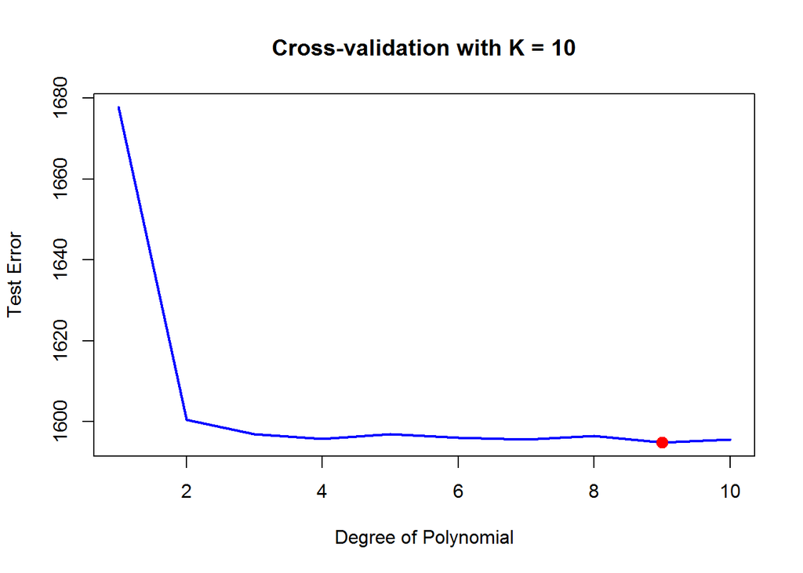

```r
set.seed(1)
k = 10; p = 10
folds = sample(1:k, length(age), replace = T)
colnames = c()
for( i in 1:p ) colnames[i] = sprintf("Poly%s", i)
cv.erros = matrix(NA, k, p, dimnames = list(NULL, colnames))
for ( i in 1:k ) {
  for ( j in 1:p ) {
    fit = lm(wage ~ poly(age, j), subset = (folds != i))
    preds = predict(fit, newdata = Wage[folds == i, ])
    cv.erros[i, j] = mean((preds - wage[folds == i])^2)
  }
}
cv.erros = apply(cv.erros, 2, mean)
plot(seq_len(p), cv.erros, type = "l", lwd = 2, col = "blue", xlab = "Degree of Polynomial", ylab = "Test Error")
title(sprintf("Cross-validation with K = %d", k))
points(which.min(cv.erros), min(cv.erros), col = "red", cex = 2, pch = 20)
```

Or we can use build-in library to finish the task of cross-validation:

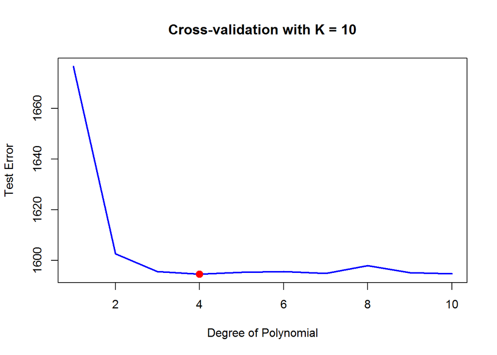

```r
library(boot)
cv.error.10 = rep(0, 10)
for ( i in 1:10 ) {
  fit = glm(wage ~ poly(age, i), data = Wage)
  cv.error.10[i] = cv.glm(Wage, fit, K = 10)$delta[1]
}
plot(cv.error.10, type = "l", lwd = 2, col = "blue", xlab = "Degree of Polynomial", ylab = "Test Error")
title("Cross-validation with K = 10")
points(which.min(cv.error.10), min(cv.error.10), col = "red", cex = 2, pch = 20)
```

The results of hypothesis testing using ANOVA is the same with the results using cross-validation (our implementation from scratch shows that $K = 9$ is the best choice, however, since we have observed that the test error were only slightly different after degree 4, we would prefer the less flexible model since it has less variance), i.e., degree of 4 shoule be chosen in the resulting polynomial.

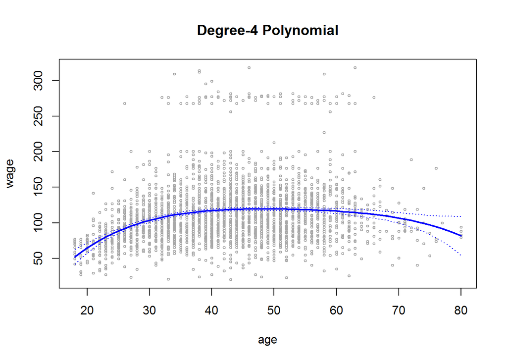

```r
fit = lm(wage~poly(age, 4), data = Wage)
agelims = range(age)
age.grid = seq(from = agelims[1], to = agelims[2])
preds = predict(fit, newdata = list(age = age.grid), se = T)
se.bands = cbind(preds$fit + 2*preds$se.fit, preds$fit - 2*preds$se.fit)
plot(age, wage, xlim = agelims, cex = .5, col = "darkgrey")
title("Degree-4 Polynomial", outer = F)
lines(age.grid, preds$fit, lwd = 2, col = "blue")
matlines(age.grid, se.bands, lwd = 1, col = "blue", lty = 3)
```

### Excercise 6b

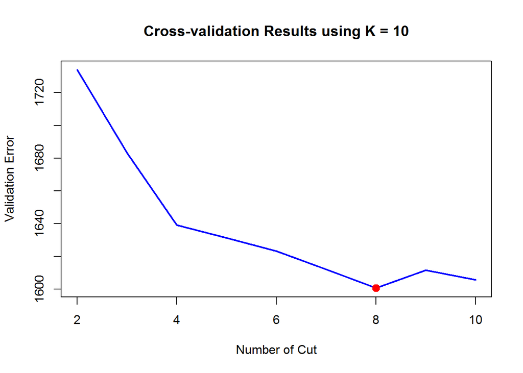

```r
set.seed(1)
all.cvs = rep(NA, 10)
for ( i in 2:10 ) {
  Wage$age.cut = cut(age, i)
  fit = glm(wage ~ age.cut, data = Wage)
  all.cvs[i] = cv.glm(Wage, fit, K = 10)$delta[1] # In CV, cut results must be stored into matrix Wage (X)
}
plot(seq(2, 10), all.cvs[-1], type = "l", lwd = 2, col = "blue", xlab = "Number of Cut", ylab = "Validation Error")
title("Cross-validation Results using K = 10")
points(which.min(all.cvs[-1]) + 1, min(all.cvs[-1]), col = "red", cex = 2, pch = 20)
```

```r
table(cut(age, which.min(all.cvs[-1]) + 1))
```

```
##
## (17.9,25.8] (25.8,33.5] (33.5,41.2]   (41.2,49]   (49,56.8] (56.8,64.5]
##         231         519         671         728         503         276
## (64.5,72.2] (72.2,80.1]
##          54          18
```

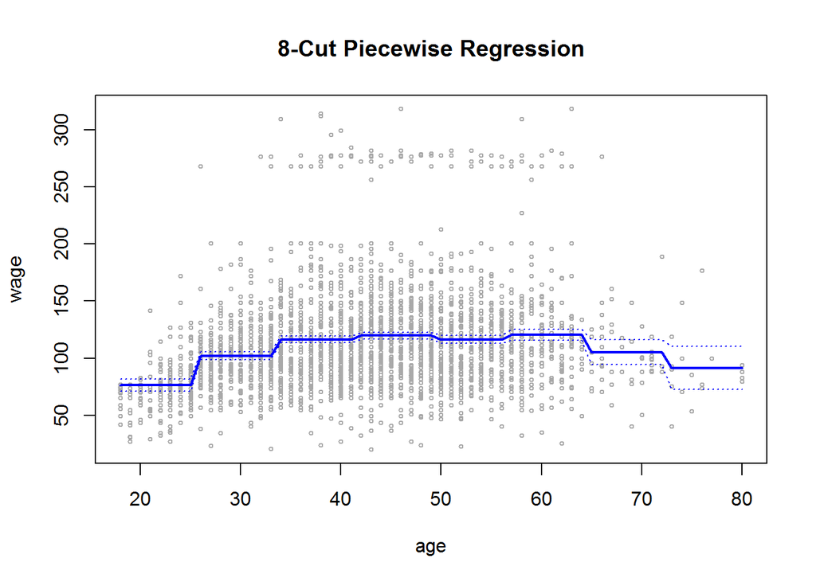

```r
fit = lm(wage~cut(age, which.min(all.cvs[-1])+1), data = Wage)
preds = predict(fit, newdata = list(age = age.grid), se = T)
se.bands = cbind(preds$fit + 2*preds$se.fit, preds$fit - 2*preds$se.fit)
plot(age, wage, xlim = agelims, cex = .5, col = "darkgrey")
title(sprintf("%d-Cut Piecewise Regression", which.min(all.cvs[-1])+1), outer = F)
lines(age.grid, preds$fit, lwd = 2, col = "blue")
matlines(age.grid, se.bands, lwd = 1, col = "blue", lty = 3)
```

```r
# clean up
rm(list = ls())
```

### Excercise 7

```r
library(splines)
library(gam)
par(mfrow = c(2,4))
names(Wage)
```

```
##  [1] "year"       "age"        "sex"        "maritl"     "race"
##  [6] "education"  "region"     "jobclass"   "health"     "health_ins"
## [11] "logwage"    "wage"
```

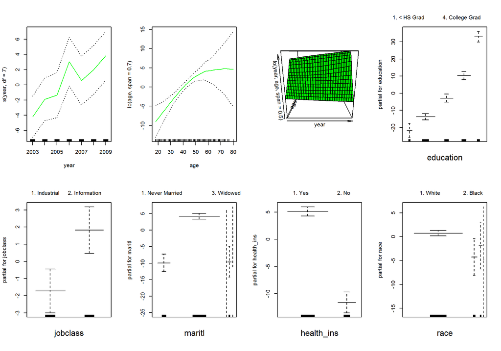

```r
gam.fit = gam(wage ~ s(year, df = 7) + lo(age, span = 0.7) + lo(year, age, span = 0.5) + education + jobclass + maritl + health_ins + race, data = Wage)
plot.gam(gam.fit, se = T, col = "green")
```

```r
gam.m1 = gam(wage ~ lo(age, span = 0.7) + lo(year, age, span = 0.5) + education + jobclass + maritl + health_ins + race, data = Wage)
gam.m2 = gam(wage ~ year + lo(age, span = 0.7) + lo(year, age, span = 0.5) + education + jobclass + maritl + health_ins + race, data = Wage)
gam.m3 = gam(wage ~ s(year, df = 7) + lo(age, span = 0.7) + lo(year, age, span = 0.5) + education + jobclass + maritl + health_ins + race, data = Wage)
anova(gam.m1, gam.m2, gam.m3)
```

```
## Analysis of Deviance Table
##
## Model 1: wage ~ lo(age, span = 0.7) + lo(year, age, span = 0.5) + education +
##     jobclass + maritl + health_ins + race
## Model 2: wage ~ year + lo(age, span = 0.7) + lo(year, age, span = 0.5) +
##     education + jobclass + maritl + health_ins + race
## Model 3: wage ~ s(year, df = 7) + lo(age, span = 0.7) + lo(year, age,
##     span = 0.5) + education + jobclass + maritl + health_ins +
##     race
##   Resid. Df Resid. Dev Df Deviance Pr(>Chi)
## 1      2977    3405748
## 2      2977    3405748  0      0.0
## 3      2972    3401854  5   3893.6   0.6383
```

```r
gam.m1 = gam(wage ~ lo(year, age, span = 0.5) + education + jobclass + maritl + health_ins + race, data = Wage)
gam.m2 = gam(wage ~ age + lo(age, span = 0.7) + lo(year, age, span = 0.5) + education + jobclass + maritl + health_ins + race, data = Wage)
gam.m3 = gam(wage ~ lo(age, span = 0.7) + lo(year, age, span = 0.5) + education + jobclass + maritl + health_ins + race, data = Wage)
anova(gam.m1, gam.m2, gam.m3)
```

```
## Analysis of Deviance Table
##
## Model 1: wage ~ lo(year, age, span = 0.5) + education + jobclass + maritl +
##     health_ins + race
## Model 2: wage ~ age + lo(age, span = 0.7) + lo(year, age, span = 0.5) +
##     education + jobclass + maritl + health_ins + race
## Model 3: wage ~ lo(age, span = 0.7) + lo(year, age, span = 0.5) + education +
##     jobclass + maritl + health_ins + race
##   Resid. Df Resid. Dev     Df Deviance Pr(>Chi)
## 1    2978.2    3406025
## 2    2977.0    3405748 1.2037   276.91   0.6998
## 3    2977.0    3405748 0.0000     0.00
```

```r
detach(Wage)
```

It is obvious that *age* has non-linear relationship with *wage*. Besides, there are sufficient evidences that *wage* differs given different qualitative predictors including *education*, *jobclass*, *maritl*, *health_ins* and *race*. We also discovered that *year* has an interaction effect with *age* therefore we don’t have to add individual basis functions for *year* and *age* (instead using a local regression on the interaction term of *year* and *age* is sufficient), which are in accord with the results of ANOVA.

### Excercise 8

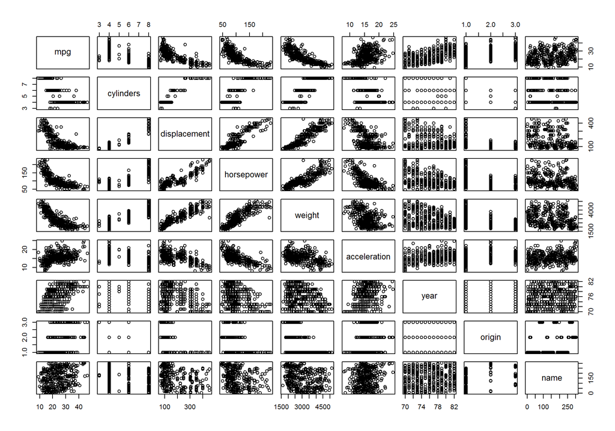

```r
rm(list = ls())
attach(Auto)
pairs(Auto)
```

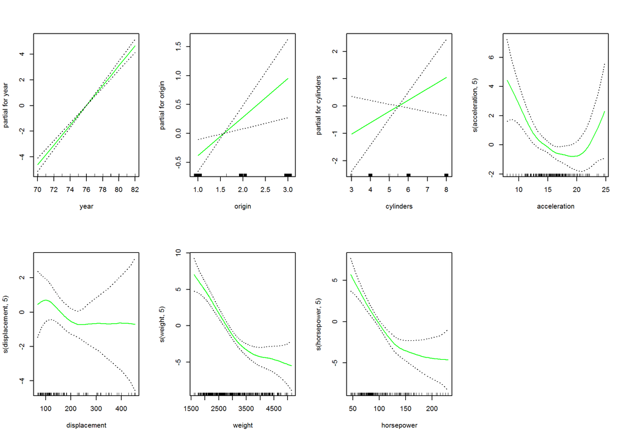

```r
gam.fit = gam(mpg ~ year + origin + cylinders + s(acceleration, 5) + s(displacement, 5) + s(weight, 5) + s(horsepower, 5), data = Auto)
par(mfrow = c(2,4))
plot.gam(gam.fit, se = T, col = "green")
detach(Auto)
par(mfrow = c(1,1))
```

Above figures indicate that predictors including *horsepower*, *weight*, *displacement* and *acceleration* show non-linear relationship with *mpg*, which can be visually confirmed with plots in `pairs(Auto)`.

### Excercise 9a

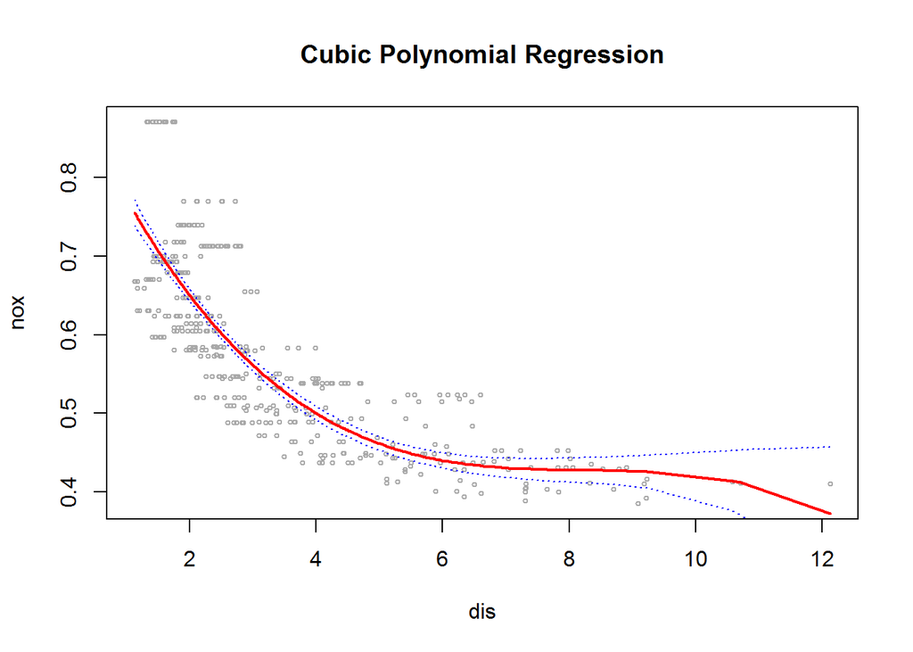

```r
library(MASS)
attach(Boston)
fit = lm(nox ~ poly(dis, 3), data = Boston)
preds = predict(fit, newdata = list(dis = sort(dis)), se = T)
se.bands = cbind(preds$fit + 2*preds$se.fit, preds$fit - 2*preds$se.fit)
plot(dis, nox, cex = .5, col = "darkgrey")
title("Cubic Polynomial Regression")
lines(sort(dis), preds$fit, lwd = 2, col = "red")
matlines(sort(dis), se.bands, lwd = 1, col = "blue", lty = 3)
```

### Excercise 9b

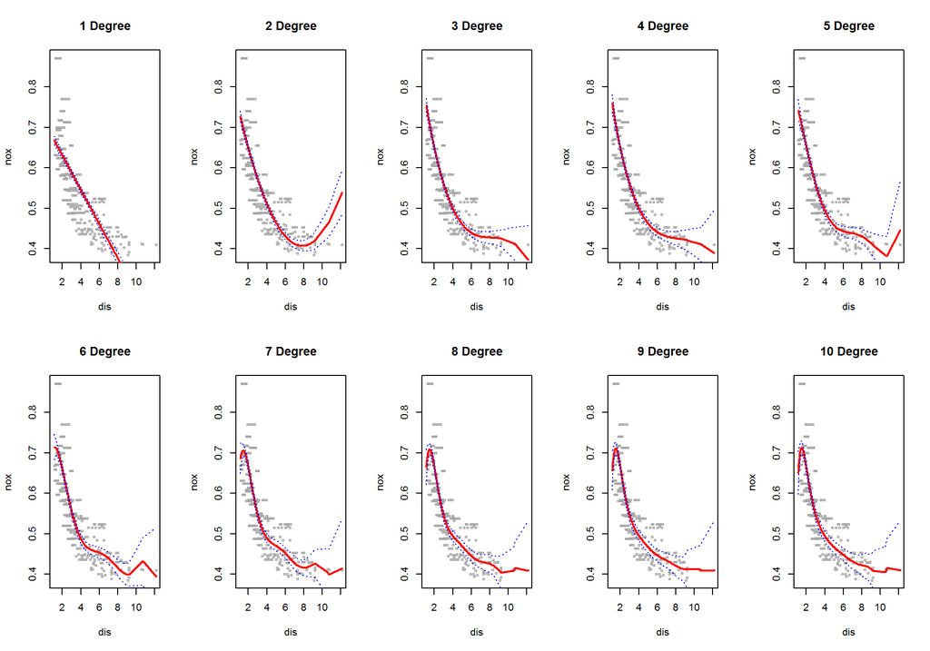

```r
par(mfrow = c(2, 5))
for ( i in 1:10 ) {
  fit = lm(nox ~ poly(dis, i), data = Boston)
  preds = predict(fit, newdata = list(dis = sort(dis)), se = T)
  se.bands = cbind(preds$fit + 2*preds$se.fit, preds$fit - 2*preds$se.fit)
  plot(dis, nox, cex = .5, col = "darkgrey")
  title(sprintf("%d Degree", i))
  lines(sort(dis), preds$fit, lwd = 2, col = "red")
  matlines(sort(dis), se.bands, lwd = 1, col = "blue", lty = 3)
}
```

```r
par(mfrow = c(1, 1))
```

### Excercise 9c

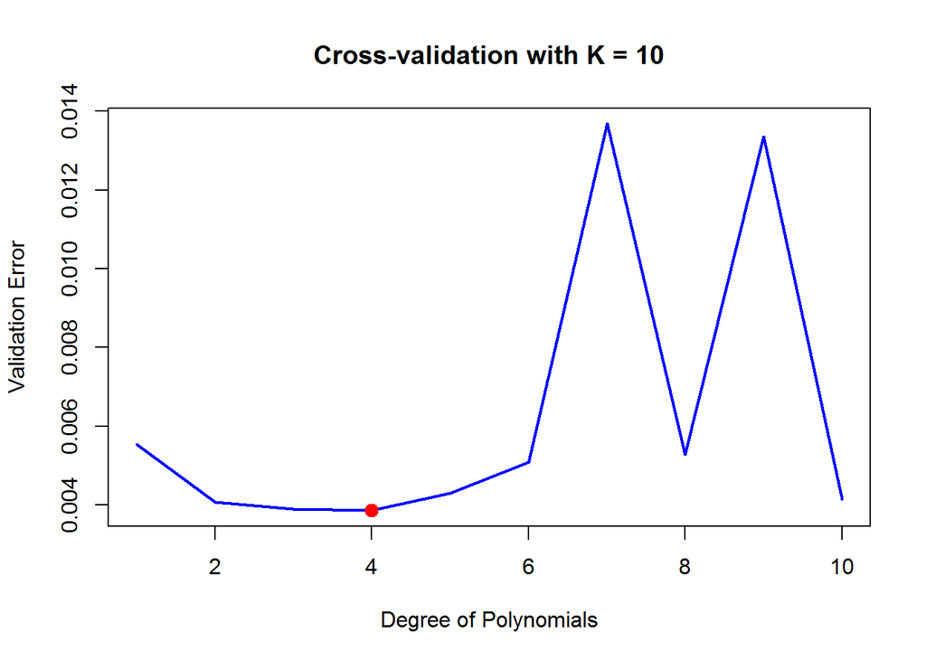

```r
set.seed(1)
all.cvs = rep(NA, 10)
for ( i in 1:10 ) {
  fit = glm(nox ~ poly(dis, i), data = Boston)
  all.cvs[i] = cv.glm(Boston, fit, K = 10)$delta[1]
}
plot(all.cvs, type = "l", lwd = 2, col = "blue", xlab = "Degree of Polynomials", ylab = "Validation Error")
title("Cross-validation with K = 10")
points(which.min(all.cvs), min(all.cvs), col = "red", cex = 2, pch = 20)
```

After testing with cross-validation, degree 4 of polynomials is our best choice.

### Excercise 9d

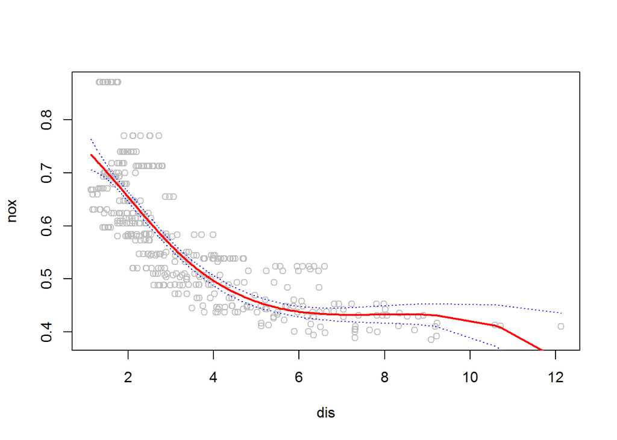

```r
library(splines)
fit = lm(nox~bs(dis, df = 4)) # For calculation of degrees of freedom in bs(), the intercept wasn't counted.
pred = predict(fit, newdata = list(dis = sort(dis)), se = T)
plot(dis, nox, col = "gray")
lines(sort(dis), pred$fit, lwd = 2, col = "red")
lines(sort(dis), pred$fit + 2*pred$se, col = "blue", lty = 3)
lines(sort(dis), pred$fit - 2*pred$se, col = "blue", lty = 3)
```

The single knot was chosen automatically based on quantiles:

```r
attr(bs(dis, df = 4), "knots")
```

```
##     50%
## 3.20745
```

### Excercise 9e

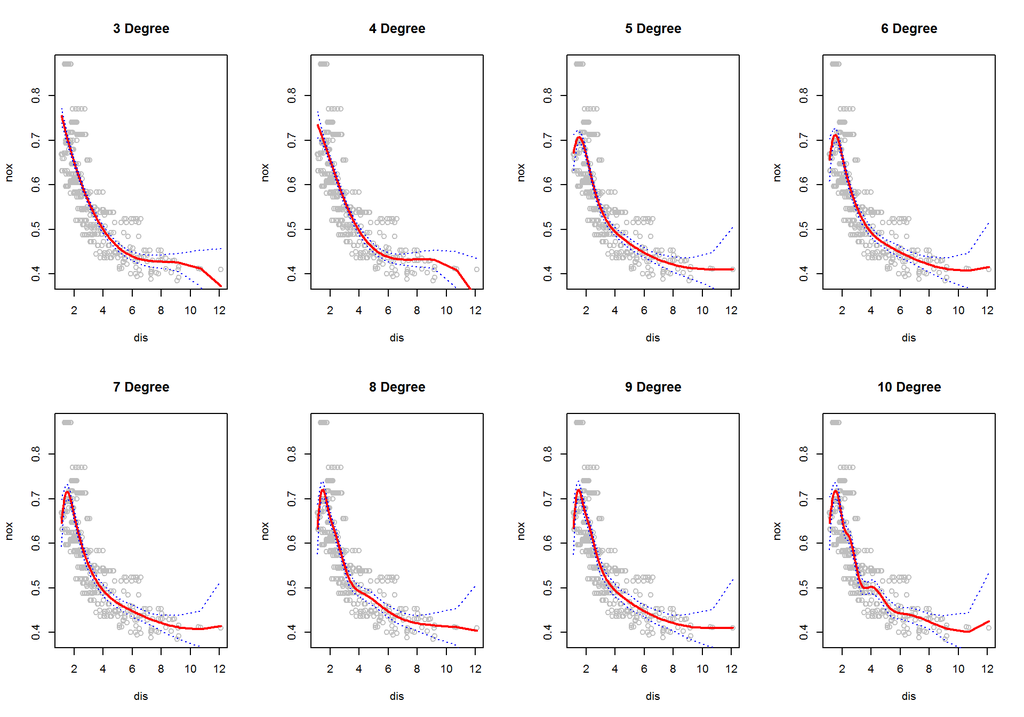

```r
par(mfrow = c(2,4))
for ( i in 3:10 ) {
  fit = lm(nox~bs(dis, df = i)) # For calculation of degrees of freedom in bs(), the intercept wasn't counted.
  pred = predict(fit, newdata = list(dis = sort(dis)), se = T)
  plot(dis, nox, col = "gray")
  title(sprintf("%d Degree", i))
  lines(sort(dis), pred$fit, lwd = 2, col = "red")
  lines(sort(dis), pred$fit + 2*pred$se, col = "blue", lty = 3)
  lines(sort(dis), pred$fit - 2*pred$se, col = "blue", lty = 3)
}
```

```r
par(mfrow = c(1,1))
```

### Excercise 9f

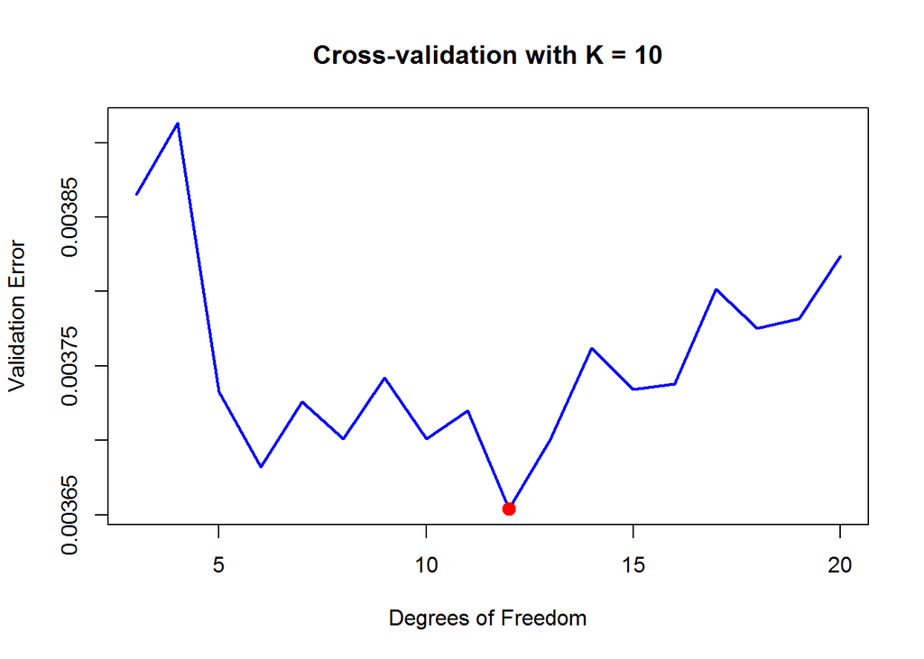

```r
set.seed(1)
all.cvs = rep(NA, 20)
for ( i in 3:20 ) {
  fit = glm(nox ~ bs(dis, df = i))
  all.cvs[i] = cv.glm(Boston, fit, K = 10)$delta[1]
}
plot(seq(3, 20), all.cvs[-(1:2)], type = "l", lwd = 2, col = "blue", xlab = "Degrees of Freedom", ylab = "Validation Error")
title("Cross-validation with K = 10")
points(which.min(all.cvs[-(1:2)])+2, min(all.cvs[-(1:2)]), col = "red", cex = 2, pch = 20)
```

After testing with cross-validation, 12 degrees of freedom is our best choice in using bs().

```r
# clean up
rm(list = ls())
```

### Excercise 10a

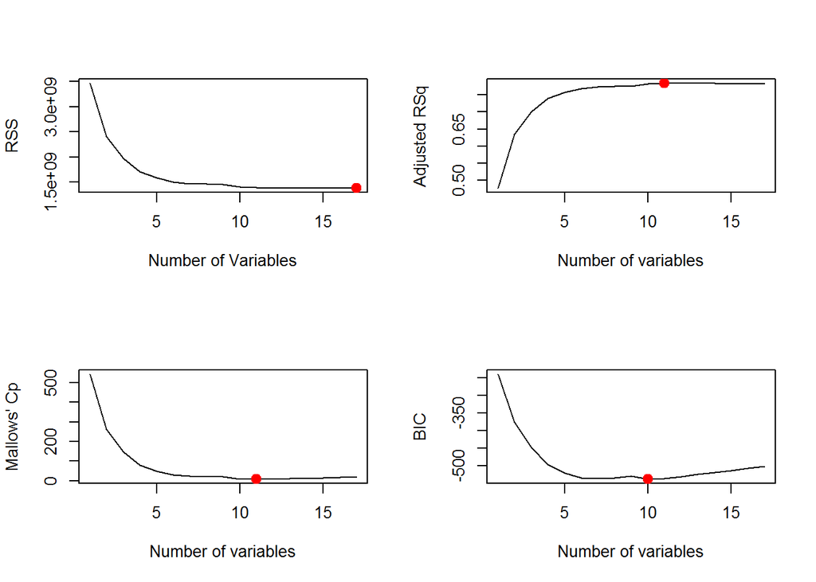

```r
library(leaps)
attach(College)
train = sample(nrow(College), nrow(College) / 2)
test = -train
train.X = College[train, ]
test.X = College[test, ]
test.Y = Outstate[test]

regfit.fwd = regsubsets(Outstate~., data = train.X, nvmax = ncol(College) - 1, method = "forward")
regfit.fwd_summary = summary(regfit.fwd)

par(mfrow = c(2,2))
plot(regfit.fwd_summary$rss, xlab = "Number of Variables", ylab = "RSS", type = "l")
points(which.min(regfit.fwd_summary$rss), min(regfit.fwd_summary$rss), col = "red", cex = 2, pch = 20)
plot(regfit.fwd_summary$adjr2, xlab = "Number of variables", ylab = "Adjusted RSq", type = "l")
points(which.max(regfit.fwd_summary$adjr2), max(regfit.fwd_summary$adjr2), col = "red", cex = 2, pch = 20)
plot(regfit.fwd_summary$cp, xlab = "Number of variables", ylab = "Mallows' Cp", type = "l")
points(which.min(regfit.fwd_summary$cp), min(regfit.fwd_summary$cp), col = "red", cex = 2, pch = 20)
plot(regfit.fwd_summary$bic, xlab = "Number of variables", ylab = "BIC", type = "l")
points(which.min(regfit.fwd_summary$bic), min(regfit.fwd_summary$bic), col = "red", cex = 2, pch = 20)
```

```r
par(mfrow = c(1,1))
```

We would choose the model based on BIC, i.e. with the following subset of predictors:

```r
coef(regfit.fwd, which.min(regfit.fwd_summary$bic))
```

```
##   (Intercept)    PrivateYes          Apps        Accept     Top25perc
## -3988.2646759  2694.0745938    -0.3252637     0.5508676    15.3425074
##    Room.Board      Personal      Terminal   perc.alumni        Expend
##     0.8549361    -0.4713496    29.2647392    43.3642170     0.2823061
##     Grad.Rate
##    37.5657583
```

### Excercise 10b

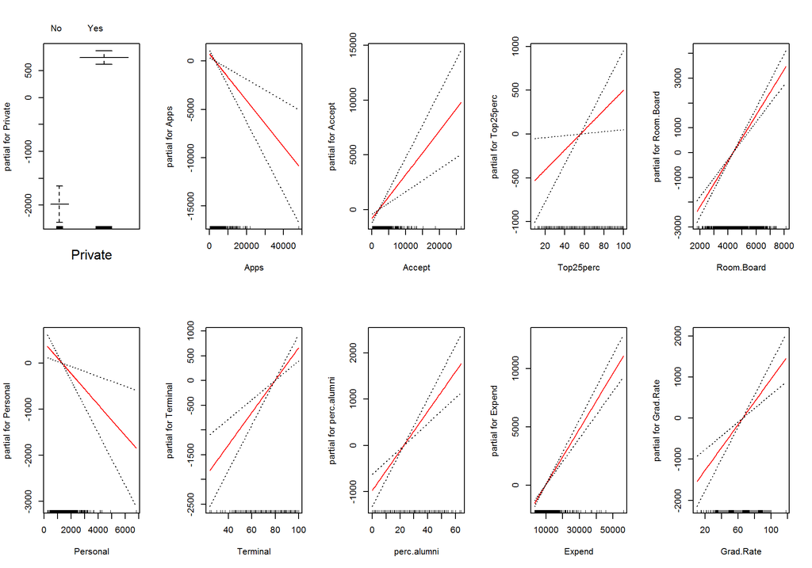

```r
library(gam)
par(mfrow = c(2,5))
gam.m = gam(Outstate ~ Private + Apps + Accept + Top25perc + Room.Board + Personal + Terminal + perc.alumni + Expend + Grad.Rate, data = College)
plot.gam(gam.m, se = T, col = "red")
```

```r
par(mfrow = c(1,1))
```

### Excercise 10c

```r
preds_all_linear = predict(gam.m, newdata = test.X)
mean((preds_all_linear - test.Y)^2)
```

```
## [1] 4125999
```

### Excercise 10d

First, let us fit the data with each predictor attached to a non-linear function:

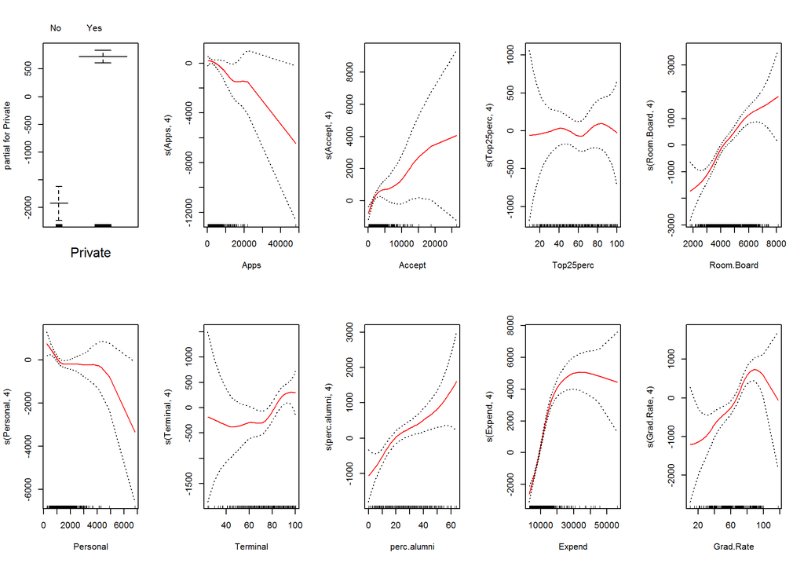

```r
par(mfrow = c(2,5))
gam.full = gam(Outstate ~ Private + s(Apps, 4) + s(Accept, 4) + s(Top25perc, 4) + s(Room.Board, 4) + s(Personal, 4) + s(Terminal, 4) + s(perc.alumni, 4) + s(Expend, 4) + s(Grad.Rate, 4), data = College)
plot.gam(gam.full , se = T, col = "red")
```

And calculate the difference of test set RSS between model with all predictors attached to linear functions and model with all predictors attached to non-linear functions:

```r
preds_all_nonlinear = predict(gam.full, newdata = test.X)
mean((preds_all_nonlinear - test.Y)^2)
```

```
## [1] 3561066
```

```r
mean((preds_all_linear - test.Y)^2) - mean((preds_all_nonlinear - test.Y)^2)
```

```
## [1] 564933.4
```

```r
par(mfrow = c(1,1))
```

As shown above, the difference is huge, therefore it is certain that the subset of predictors are non-linear to the response in the true relationship. Let us find out those predictors by obtaining different models and test them using anova. Suppose we want to test whether predictor ${{\bf{x}}_j}$ should be avoided, or attached to a linear/non-linear function, the following models should be obtained and tested with ANOVA while holding functions of other predictors fixed:

1. Model without predictor ${\bf x}_j$.
2. Model with predictor ${\bf x}_j$ attached to a linear function.
3. Model with predictor ${\bf x}_j$ attached to a non-linear function.

```r
gam.m1 = gam(Outstate ~ Private + s(Accept, 4) + s(Top25perc, 4) + s(Room.Board, 4) + s(Personal, 4) + s(Terminal, 4) + s(perc.alumni, 4) + s(Expend, 4) + s(Grad.Rate, 4), data = College)
gam.m2 = gam(Outstate ~ Private + Apps + s(Accept, 4) + s(Top25perc, 4) + s(Room.Board, 4) + s(Personal, 4) + s(Terminal, 4) + s(perc.alumni, 4) + s(Expend, 4) + s(Grad.Rate, 4), data = College)
gam.m3 = gam(Outstate ~ Private + s(Apps, 4) + s(Accept, 4) + s(Top25perc, 4) + s(Room.Board, 4) + s(Personal, 4) + s(Terminal, 4) + s(perc.alumni, 4) + s(Expend, 4) + s(Grad.Rate, 4), data = College)
anova(gam.m1, gam.m2, gam.m3, test = "F")
```

```
## Analysis of Deviance Table
##
## Model 1: Outstate ~ Private + s(Accept, 4) + s(Top25perc, 4) + s(Room.Board,
##     4) + s(Personal, 4) + s(Terminal, 4) + s(perc.alumni, 4) +
##     s(Expend, 4) + s(Grad.Rate, 4)
## Model 2: Outstate ~ Private + Apps + s(Accept, 4) + s(Top25perc, 4) +
##     s(Room.Board, 4) + s(Personal, 4) + s(Terminal, 4) + s(perc.alumni,
##     4) + s(Expend, 4) + s(Grad.Rate, 4)
## Model 3: Outstate ~ Private + s(Apps, 4) + s(Accept, 4) + s(Top25perc,
##     4) + s(Room.Board, 4) + s(Personal, 4) + s(Terminal, 4) +
##     s(perc.alumni, 4) + s(Expend, 4) + s(Grad.Rate, 4)
##   Resid. Df Resid. Dev     Df Deviance      F Pr(>F)
## 1       743 2457447016
## 2       742 2450698453 1.0000  6748562 2.0452 0.1531
## 3       739 2438530706 3.0002 12167747 1.2291 0.2981
```

The result indicates that predictor *App* should be avoided.

```r
gam.m1 = gam(Outstate ~ Private + s(Top25perc, 4) + s(Room.Board, 4) + s(Personal, 4) + s(Terminal, 4) + s(perc.alumni, 4) + s(Expend, 4) + s(Grad.Rate, 4), data = College)
gam.m2 = gam(Outstate ~ Private + Accept + s(Top25perc, 4) + s(Room.Board, 4) + s(Personal, 4) + s(Terminal, 4) + s(perc.alumni, 4) + s(Expend, 4) + s(Grad.Rate, 4), data = College)
gam.m3 = gam(Outstate ~ Private + s(Accept, 4) + s(Top25perc, 4) + s(Room.Board, 4) + s(Personal, 4) + s(Terminal, 4) + s(perc.alumni, 4) + s(Expend, 4) + s(Grad.Rate, 4), data = College)
anova(gam.m1, gam.m2, gam.m3, test = "F")
```

```
## Analysis of Deviance Table
##
## Model 1: Outstate ~ Private + s(Top25perc, 4) + s(Room.Board, 4) + s(Personal,
##     4) + s(Terminal, 4) + s(perc.alumni, 4) + s(Expend, 4) +
##     s(Grad.Rate, 4)
## Model 2: Outstate ~ Private + Accept + s(Top25perc, 4) + s(Room.Board,
##     4) + s(Personal, 4) + s(Terminal, 4) + s(perc.alumni, 4) +
##     s(Expend, 4) + s(Grad.Rate, 4)
## Model 3: Outstate ~ Private + s(Accept, 4) + s(Top25perc, 4) + s(Room.Board,
##     4) + s(Personal, 4) + s(Terminal, 4) + s(perc.alumni, 4) +
##     s(Expend, 4) + s(Grad.Rate, 4)
##   Resid. Df Resid. Dev Df Deviance      F    Pr(>F)
## 1       747 2551122758
## 2       746 2548823351  1  2299407 0.6952    0.4047
## 3       743 2457447016  3 91376335 9.2090 5.492e-06 ***
## ---
## Signif. codes:  0 '***' 0.001 '**' 0.01 '*' 0.05 '.' 0.1 ' ' 1
```

The result indicates that predictor *Accept* should be attched to a non-linear function.

```r
gam.m1 = gam(Outstate ~ Private + s(Accept, 4) + s(Room.Board, 4) + s(Personal, 4) + s(Terminal, 4) + s(perc.alumni, 4) + s(Expend, 4) + s(Grad.Rate, 4), data = College)
gam.m2 = gam(Outstate ~ Private + s(Accept, 4) + Top25perc + s(Room.Board, 4) + s(Personal, 4) + s(Terminal, 4) + s(perc.alumni, 4) + s(Expend, 4) + s(Grad.Rate, 4), data = College)
gam.m3 = gam(Outstate ~ Private + s(Accept, 4) + s(Top25perc, 4) + s(Room.Board, 4) + s(Personal, 4) + s(Terminal, 4) + s(perc.alumni, 4) + s(Expend, 4) + s(Grad.Rate, 4), data = College)
anova(gam.m1, gam.m2, gam.m3, test = "F")
```

```
## Analysis of Deviance Table
##
## Model 1: Outstate ~ Private + s(Accept, 4) + s(Room.Board, 4) + s(Personal,
##     4) + s(Terminal, 4) + s(perc.alumni, 4) + s(Expend, 4) +
##     s(Grad.Rate, 4)
## Model 2: Outstate ~ Private + s(Accept, 4) + Top25perc + s(Room.Board,
##     4) + s(Personal, 4) + s(Terminal, 4) + s(perc.alumni, 4) +
##     s(Expend, 4) + s(Grad.Rate, 4)
## Model 3: Outstate ~ Private + s(Accept, 4) + s(Top25perc, 4) + s(Room.Board,
##     4) + s(Personal, 4) + s(Terminal, 4) + s(perc.alumni, 4) +
##     s(Expend, 4) + s(Grad.Rate, 4)
##   Resid. Df Resid. Dev     Df Deviance      F Pr(>F)
## 1       747 2462915936
## 2       746 2462701416 1.0000   214521 0.0649 0.7990
## 3       743 2457447016 3.0002  5254400 0.5295 0.6621
```

The result indicates that predictor *Top25perc* should be avoided.

```r
gam.m1 = gam(Outstate ~ Private + s(Accept, 4) + s(Personal, 4) + s(Terminal, 4) + s(perc.alumni, 4) + s(Expend, 4) + s(Grad.Rate, 4), data = College)
gam.m2 = gam(Outstate ~ Private + s(Accept, 4) + Room.Board + s(Personal, 4) + s(Terminal, 4) + s(perc.alumni, 4) + s(Expend, 4) + s(Grad.Rate, 4), data = College)
gam.m3 = gam(Outstate ~ Private + s(Accept, 4) + s(Room.Board, 4) + s(Personal, 4) + s(Terminal, 4) + s(perc.alumni, 4) + s(Expend, 4) + s(Grad.Rate, 4), data = College)
anova(gam.m1, gam.m2, gam.m3, test = "F")
```

```
## Analysis of Deviance Table
##
## Model 1: Outstate ~ Private + s(Accept, 4) + s(Personal, 4) + s(Terminal,
##     4) + s(perc.alumni, 4) + s(Expend, 4) + s(Grad.Rate, 4)
## Model 2: Outstate ~ Private + s(Accept, 4) + Room.Board + s(Personal,
##     4) + s(Terminal, 4) + s(perc.alumni, 4) + s(Expend, 4) +
##     s(Grad.Rate, 4)
## Model 3: Outstate ~ Private + s(Accept, 4) + s(Room.Board, 4) + s(Personal,
##     4) + s(Terminal, 4) + s(perc.alumni, 4) + s(Expend, 4) +
##     s(Grad.Rate, 4)
##   Resid. Df Resid. Dev Df  Deviance       F  Pr(>F)
## 1       751 2720834002
## 2       750 2485927741  1 234906260 71.2469 < 2e-16 ***
## 3       747 2462915936  3  23011805  2.3265 0.07345 .
## ---
## Signif. codes:  0 '***' 0.001 '**' 0.01 '*' 0.05 '.' 0.1 ' ' 1
```

The result indicates that predictor *Room.Board* should be attched to a linear function.

```r
gam.m1 = gam(Outstate ~ Private + s(Accept, 4) + Room.Board + s(Terminal, 4) + s(perc.alumni, 4) + s(Expend, 4) + s(Grad.Rate, 4), data = College)
gam.m2 = gam(Outstate ~ Private + s(Accept, 4) + Room.Board + Personal + s(Terminal, 4) + s(perc.alumni, 4) + s(Expend, 4) + s(Grad.Rate, 4), data = College)
gam.m3 = gam(Outstate ~ Private + s(Accept, 4) + Room.Board + s(Personal, 4) + s(Terminal, 4) + s(perc.alumni, 4) + s(Expend, 4) + s(Grad.Rate, 4), data = College)
anova(gam.m1, gam.m2, gam.m3, test = "F")
```

```
## Analysis of Deviance Table
##
## Model 1: Outstate ~ Private + s(Accept, 4) + Room.Board + s(Terminal,
##     4) + s(perc.alumni, 4) + s(Expend, 4) + s(Grad.Rate, 4)
## Model 2: Outstate ~ Private + s(Accept, 4) + Room.Board + Personal + s(Terminal,
##     4) + s(perc.alumni, 4) + s(Expend, 4) + s(Grad.Rate, 4)
## Model 3: Outstate ~ Private + s(Accept, 4) + Room.Board + s(Personal,
##     4) + s(Terminal, 4) + s(perc.alumni, 4) + s(Expend, 4) +
##     s(Grad.Rate, 4)
##   Resid. Df Resid. Dev Df Deviance       F   Pr(>F)
## 1       754 2554986414
## 2       753 2521773629  1 33212785 10.0202 0.001611 **
## 3       750 2485927741  3 35845888  3.6048 0.013191 *
## ---
## Signif. codes:  0 '***' 0.001 '**' 0.01 '*' 0.05 '.' 0.1 ' ' 1
```

The result indicates that predictor *Personal* should be attched to a non-linear function.

```r
gam.m1 = gam(Outstate ~ Private + s(Accept, 4) + Room.Board + s(Personal, 4) + s(perc.alumni, 4) + s(Expend, 4) + s(Grad.Rate, 4), data = College)
gam.m2 = gam(Outstate ~ Private + s(Accept, 4) + Room.Board + s(Personal, 4) + Terminal + s(perc.alumni, 4) + s(Expend, 4) + s(Grad.Rate, 4), data = College)
gam.m3 = gam(Outstate ~ Private + s(Accept, 4) + Room.Board + s(Personal, 4) + s(Terminal, 4) + s(perc.alumni, 4) + s(Expend, 4) + s(Grad.Rate, 4), data = College)
anova(gam.m1, gam.m2, gam.m3, test = "F")
```

```
## Analysis of Deviance Table
##
## Model 1: Outstate ~ Private + s(Accept, 4) + Room.Board + s(Personal,
##     4) + s(perc.alumni, 4) + s(Expend, 4) + s(Grad.Rate, 4)
## Model 2: Outstate ~ Private + s(Accept, 4) + Room.Board + s(Personal,
##     4) + Terminal + s(perc.alumni, 4) + s(Expend, 4) + s(Grad.Rate,
##     4)
## Model 3: Outstate ~ Private + s(Accept, 4) + Room.Board + s(Personal,
##     4) + s(Terminal, 4) + s(perc.alumni, 4) + s(Expend, 4) +
##     s(Grad.Rate, 4)
##   Resid. Df Resid. Dev     Df Deviance      F  Pr(>F)
## 1       754 2515748775
## 2       753 2501647390 1.0000 14101385 4.2544 0.03949 *
## 3       750 2485927741 2.9998 15719649 1.5810 0.19258
## ---
## Signif. codes:  0 '***' 0.001 '**' 0.01 '*' 0.05 '.' 0.1 ' ' 1
```

The result indicates that predictor *Terminal* should be attched to a linear function.

```r
gam.m1 = gam(Outstate ~ Private + s(Accept, 4) + Room.Board + s(Personal, 4) + Terminal + s(Expend, 4) + s(Grad.Rate, 4), data = College)
gam.m2 = gam(Outstate ~ Private + s(Accept, 4) + Room.Board + s(Personal, 4) + Terminal + perc.alumni + s(Expend, 4) + s(Grad.Rate, 4), data = College)
gam.m3 = gam(Outstate ~ Private + s(Accept, 4) + Room.Board + s(Personal, 4) + Terminal + s(perc.alumni, 4) + s(Expend, 4) + s(Grad.Rate, 4), data = College)
anova(gam.m1, gam.m2, gam.m3, test = "F")
```

```
## Analysis of Deviance Table
##
## Model 1: Outstate ~ Private + s(Accept, 4) + Room.Board + s(Personal,
##     4) + Terminal + s(Expend, 4) + s(Grad.Rate, 4)
## Model 2: Outstate ~ Private + s(Accept, 4) + Room.Board + s(Personal,
##     4) + Terminal + perc.alumni + s(Expend, 4) + s(Grad.Rate,
##     4)
## Model 3: Outstate ~ Private + s(Accept, 4) + Room.Board + s(Personal,
##     4) + Terminal + s(perc.alumni, 4) + s(Expend, 4) + s(Grad.Rate,
##     4)
##   Resid. Df Resid. Dev Df Deviance       F  Pr(>F)
## 1       757 2601021286
## 2       756 2514606493  1 86414793 26.0110 4.3e-07 ***
## 3       753 2501647390  3 12959102  1.3002  0.2732
## ---
## Signif. codes:  0 '***' 0.001 '**' 0.01 '*' 0.05 '.' 0.1 ' ' 1
```

The result indicates that predictor *perc.alumni* should be attched to a linear function.

```r
gam.m1 = gam(Outstate ~ Private + s(Accept, 4) + Room.Board + s(Personal, 4) + Terminal + perc.alumni + s(Grad.Rate, 4), data = College)
gam.m2 = gam(Outstate ~ Private + s(Accept, 4) + Room.Board + s(Personal, 4) + Terminal + perc.alumni + Expend + s(Grad.Rate, 4), data = College)
gam.m3 = gam(Outstate ~ Private + s(Accept, 4) + Room.Board + s(Personal, 4) + Terminal + perc.alumni + s(Expend, 4) + s(Grad.Rate, 4), data = College)
anova(gam.m1, gam.m2, gam.m3, test = "F")
```

```
## Analysis of Deviance Table
##
## Model 1: Outstate ~ Private + s(Accept, 4) + Room.Board + s(Personal,
##     4) + Terminal + perc.alumni + s(Grad.Rate, 4)
## Model 2: Outstate ~ Private + s(Accept, 4) + Room.Board + s(Personal,
##     4) + Terminal + perc.alumni + Expend + s(Grad.Rate, 4)
## Model 3: Outstate ~ Private + s(Accept, 4) + Room.Board + s(Personal,
##     4) + Terminal + perc.alumni + s(Expend, 4) + s(Grad.Rate,
##     4)
##   Resid. Df Resid. Dev Df  Deviance      F    Pr(>F)
## 1       760 3543858824
## 2       759 2928615741  1 615243082 184.97 < 2.2e-16 ***
## 3       756 2514606493  3 414009249  41.49 < 2.2e-16 ***
## ---
## Signif. codes:  0 '***' 0.001 '**' 0.01 '*' 0.05 '.' 0.1 ' ' 1
```

```r
gam.m1 = gam(Outstate ~ Private + s(Accept, 4) + Room.Board + s(Personal, 4) + Terminal + perc.alumni + Expend, data = College)
gam.m2 = gam(Outstate ~ Private + s(Accept, 4) + Room.Board + s(Personal, 4) + Terminal + perc.alumni + Expend + Grad.Rate, data = College)
gam.m3 = gam(Outstate ~ Private + s(Accept, 4) + Room.Board + s(Personal, 4) + Terminal + perc.alumni + Expend + s(Grad.Rate, 4), data = College)
anova(gam.m1, gam.m2, gam.m3, test = "F")
```

```
## Analysis of Deviance Table
##
## Model 1: Outstate ~ Private + s(Accept, 4) + Room.Board + s(Personal,
##     4) + Terminal + perc.alumni + Expend
## Model 2: Outstate ~ Private + s(Accept, 4) + Room.Board + s(Personal,
##     4) + Terminal + perc.alumni + Expend + Grad.Rate
## Model 3: Outstate ~ Private + s(Accept, 4) + Room.Board + s(Personal,
##     4) + Terminal + perc.alumni + Expend + s(Grad.Rate, 4)
##   Resid. Df Resid. Dev Df Deviance      F    Pr(>F)
## 1       763 3060566982
## 2       762 2981527648  1 79039334 20.484 6.977e-06 ***
## 3       759 2928615741  3 52911907  4.571  0.003504 **
## ---
## Signif. codes:  0 '***' 0.001 '**' 0.01 '*' 0.05 '.' 0.1 ' ' 1
```

Finally, we obtained our model as:

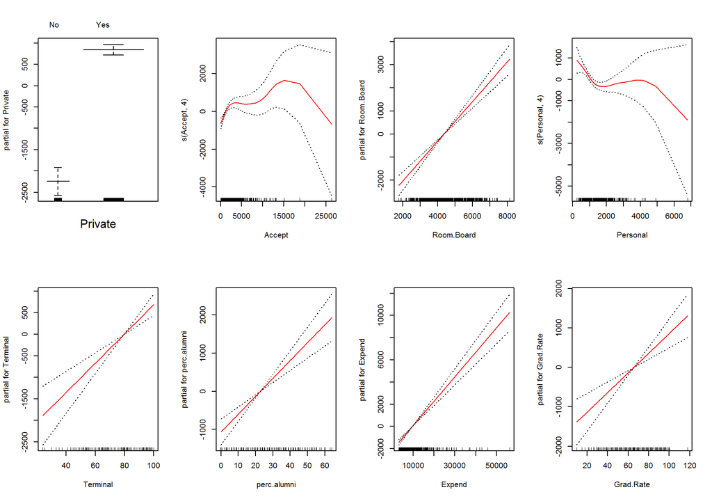

```r
gam.final = gam(Outstate ~ Private + s(Accept, 4) + Room.Board + s(Personal, 4) + Terminal + perc.alumni + Expend + Grad.Rate, data = College)
par(mfrow = c(2,4))
plot.gam(gam.final, se = T, col = "red")
```

```r
preds_final = predict(gam.final, newdata = test.X)
mean((preds_final - test.Y)^2)
```

```
## [1] 4073175
```

```r
par(mfrow = c(1,1))
```

We see above that at the boundary region of plots of *Accept* vs. response and *Personal* vs. response, the confidence bands appear fairly wild. Therefore, we may try natural spline regression instead of smoothing regression for better fit:

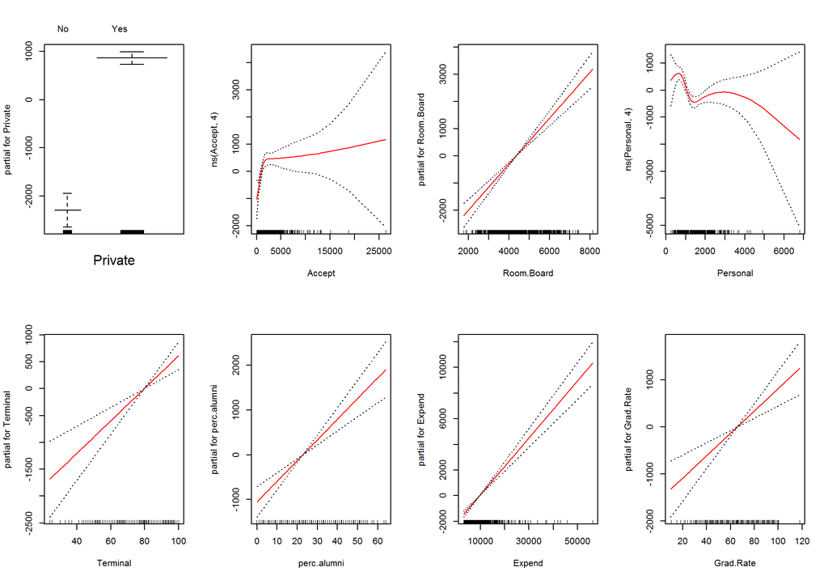

```r
gam.final = gam(Outstate ~ Private + ns(Accept, 4) + Room.Board + ns(Personal, 4) + Terminal + perc.alumni + Expend + Grad.Rate, data = College)
par(mfrow = c(2,4))
plot.gam(gam.final, se = T, col = "red")
```

```r
preds_final = predict(gam.final, newdata = test.X)
mean((preds_final - test.Y)^2)
```

```
## [1] 4103826
```

```r
par(mfrow = c(1,1))
```

The test set RSS of the model using natural spline for predictors that have non-linear relationship with the response is slighly higher than the model using smoothing spline, therefore, we choose the model using smoothing spline but with higher degrees of freedom:

```r
gam.final = gam(Outstate ~ Private + s(Accept, 8) + Room.Board + s(Personal, 8) + Terminal + perc.alumni + Expend + Grad.Rate, data = College)
preds_final = predict(gam.final, newdata = test.X)
mean((preds_final - test.Y)^2)
```

```
## [1] 4019751
```

Compare the final model with the full model:

```r
mean((preds_all_nonlinear - test.Y)^2) - mean((preds_final - test.Y)^2)
```

```
## [1] -458685.2
```

Compare the final model with the linear model (the model with all predictors attached to linear functions):

```r
mean((preds_all_linear - test.Y)^2) - mean((preds_final - test.Y)^2)
```

```
## [1] 106248.2
```

Visualization result:

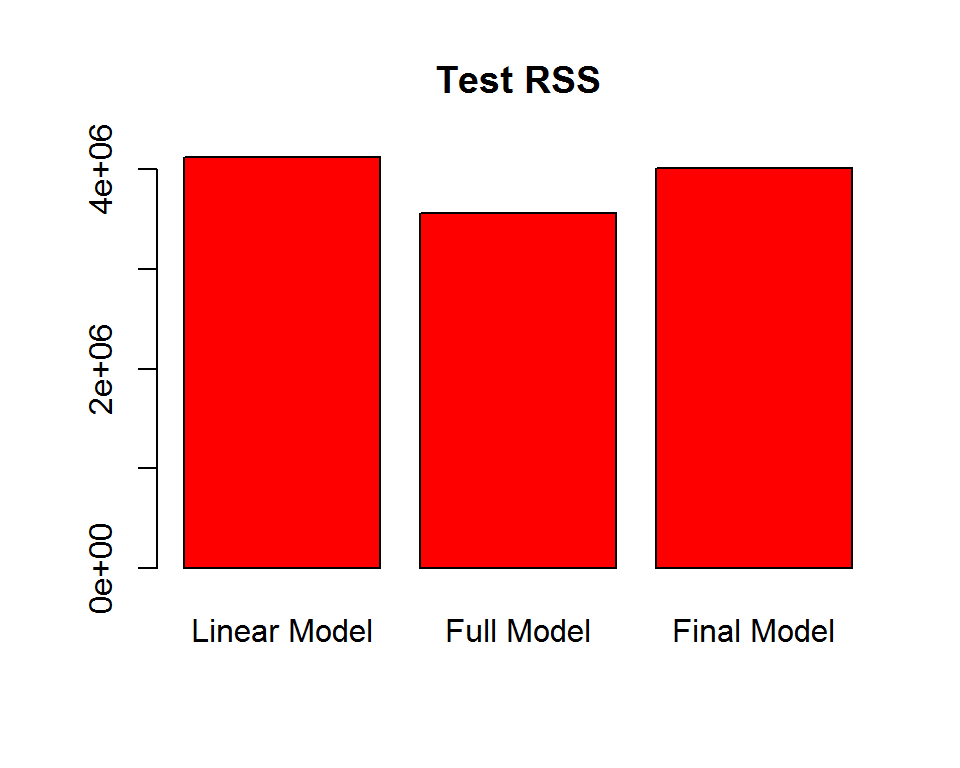

```r
barplot(c(mean((preds_all_linear - test.Y)^2), mean((preds_all_nonlinear - test.Y)^2), mean((preds_final - test.Y)^2)), col = "red", names.arg = c("Linear Model", "Full Model", "Final Model"), main = "Test RSS")
```

### Excercise 11a

```r
set.seed(1)
beta_0 = -3.8; beta_1 = 1.7; beta_2 = 3.8
x_1 = rnorm(100); x_2 = rnorm(100)
error = rnorm(100, 0.3, 2.2)
y = beta_0 + beta_1 * x_1 + beta_2 * x_2 + error
```

### Excercise 11b

```r
beta_1 = 0
```

### Excercise 11c

```r
a = y - beta_1 * x_1
beta_2 = lm(a ~ x_2)$coef[2]
```

### Excercise 11d

```r
a = y - beta_2 * x_2
beta_1 = lm(a ~ x_1)$coef[2]
```

### Excercise 11e

```r
beta_1s = c(); beta_2s = c(); beta_0s = c()
beta_1s[0] = 0; beta_1s[1] = 0; beta_2s[1] = 0
for( i in 2:11 ) { # we don't have to iterate 1000 times when using this data set
  a = y - beta_1s[i-1] * x_1
  beta_2s[i] = lm(a ~ x_2)$coef[2]

  a = y - beta_2s[i] * x_2
  beta_1s[i] = lm(a ~ x_1)$coef[2]

  beta_0s[i] = lm(a ~ x_1)$coef[1]

  print("-------------------------------------")
  print(sprintf("Iteration %d", i - 1))
  print(sprintf("Estimated Beta0 = %f", beta_0s[i]))
  print(sprintf("Estimated Beta1 = %f", beta_1s[i]))
  print(sprintf("Estimated Beta2 = %f", beta_2s[i]))
}
```

```
## [1] "-------------------------------------"
## [1] "Iteration 1"
## [1] "Estimated Beta0 = -3.444284"
## [1] "Estimated Beta1 = 1.746441"
## [1] "Estimated Beta2 = 3.680745"
## [1] "-------------------------------------"
## [1] "Iteration 2"
## [1] "Estimated Beta0 = -3.444222"
## [1] "Estimated Beta1 = 1.746442"
## [1] "Estimated Beta2 = 3.682373"
## [1] "-------------------------------------"
## [1] "Iteration 3"
## [1] "Estimated Beta0 = -3.444222"
## [1] "Estimated Beta1 = 1.746442"
## [1] "Estimated Beta2 = 3.682373"
```

[output cut: 35 more lines]

### Excercise 11f

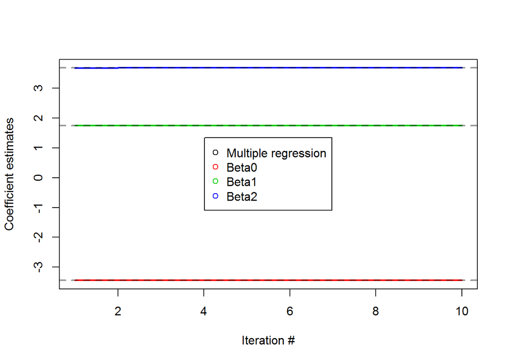

```r
fit = lm(y ~ x_1 + x_2)
require(grDevices)
matplot(cbind(beta_0s[-1], beta_1s[-1], beta_2s[-1]), col = 2:4, type = "l", lty = 1, lwd = 2, xlab = "Iteration #", ylab = "Coefficient estimates")
abline(h = fit$coef[1], lty = "dashed", lwd = 2, col = rgb(0, 0, 0, alpha = 0.4))
abline(h = fit$coef[2], lty = "dashed", lwd = 2, col = rgb(0, 0, 0, alpha = 0.4))
abline(h = fit$coef[3], lty = "dashed", lwd = 2, col = rgb(0, 0, 0, alpha = 0.4))
legend("center", legend = c("Multiple regression", "Beta0", "Beta1", "Beta2"), col = 1:4, pch = 1)
```

As we see above, the coefficient estimates obtained from multiple regression are identical to the results obtained using backfitting.

### Excercise 11g

Just one backfitting iteration is sufficient to obtain a good approximation to the multiple regression coefficient estimates.

### Excercise 12

```r
set.seed(1)
n = 1000; p = 100
betas = runif(p + 1, -10, 10)
error = rnorm(n, mean = 0, sd = 2.1)
xs = matrix(NA, nrow = n, ncol = p + 1)
xs[, 1] = rep(1, n)
for ( i in 1:p ) {
  xs[, i+1] = rnorm(n, mean = runif(1, -10, 10), sd = runif(1, 0.5, 3))
}
y = xs %*% betas  + error
xs = xs[, -1] # to simplify calculation
```

Using backfitting procedure:

```r
N_iteration = 10
estimated_betas = matrix(0, nrow = N_iteration, ncol = p) # excluding beta0 to simplify calculation
error = c()
error[1] = mean((y - xs %*% estimated_betas[1, ])^2)
for ( i in 1:N_iteration ) {  # NOTE: priority of ":" is greater than "+-"
  for ( j in 1:p ) {
    if ( i == 1 ) {
      a = y - xs[, -j] %*% estimated_betas[i, -j]
      estimated_betas[i, j] = lm(a ~ xs[, j])$coef[2]
    } else {
      a = y - xs[, -j] %*% estimated_betas[i-1, -j]
      estimated_betas[i, j] = lm(a ~ xs[, j])$coef[2]
    }
  }
  error[i+1] = mean((y - xs %*% estimated_betas[i, ])^2)
}
```

Using multiple regression:

```r
fit = lm(y ~ ., data = data.frame(x = xs, y = y))
```

Visualize the results:

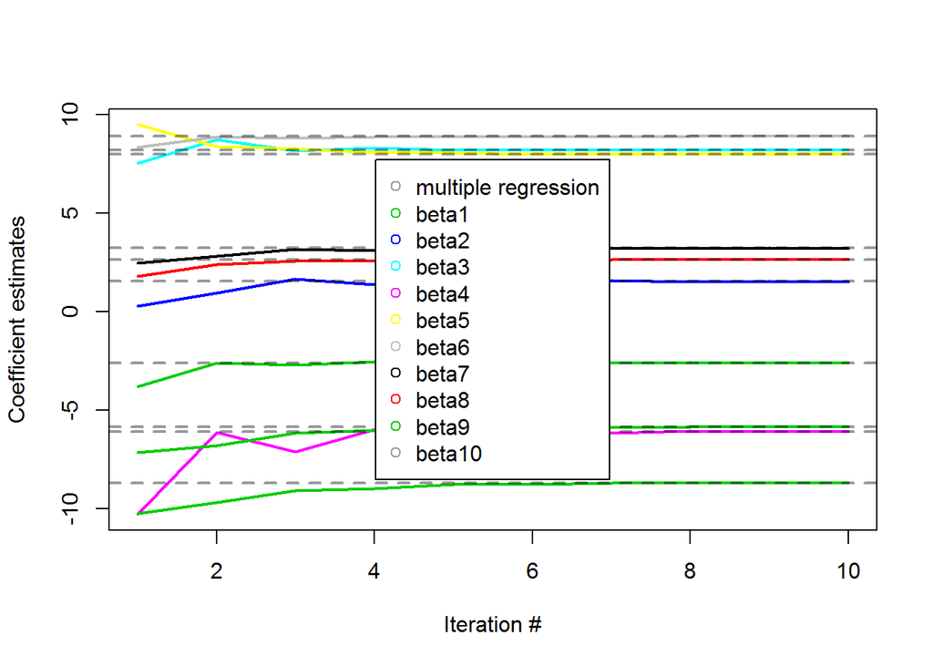

```r
N_show_beta = 10
matplot(estimated_betas[, 1:N_show_beta], lwd = 2, col = 2:N_show_beta+1, type = "l", lty = 1, xlab = "Iteration #", ylab = "Coefficient estimates")
for ( i in 1:N_show_beta ) {
  abline(h = fit$coef[i+1], lty = "dashed", lwd = 2, col = rgb(0, 0, 0, alpha = 0.4))
}
beta_names = c()
for ( i in 1:N_show_beta ) {
  beta_names[i] = sprintf("beta%d", i)
}
legend("center", legend = c("multiple regression", beta_names), col = c(rgb(0, 0, 0, alpha = 0.4), 2:N_show_beta+1), pch = 1)
```

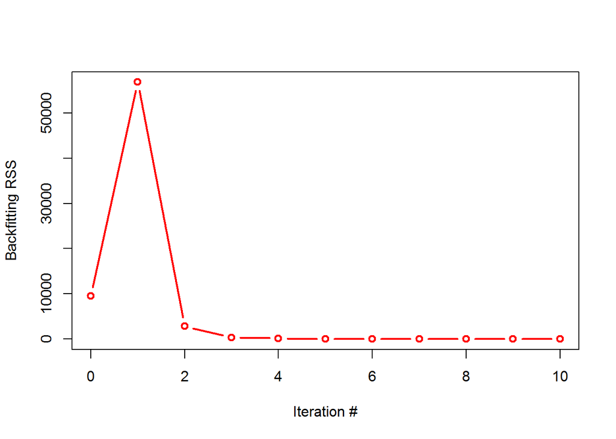

```r
plot(seq(0, N_iteration), error, xlab  = "Iteration #", col = "red", lwd = 2, type = "b", ylab = "Backfitting RSS")
```

As shown above, after 4 iterations, the backfitting approach can obtain good approximation to the multiple regression coeffcieint estimates.